# GFP distribution: ontogeny data

#### GFP expression dynamics in naive CD4 and CD8 T cells.

Data from Rag-GFP Ki67-RFP mice capturing the time course of expression of GFP within recently divided (Ki67$^\text{high}$) and non-divided (Ki67$^\text{low}$) naive CD4 and CD8 T cells. Proportions of GFP$^+$ cells within these specific subsets in spleen (red dots) and in lymph node (blue dots) completely overlap with each other. Further, GFP$^+$ fraction is almost absent in recently divided naive CD4 and CD8 T cells.

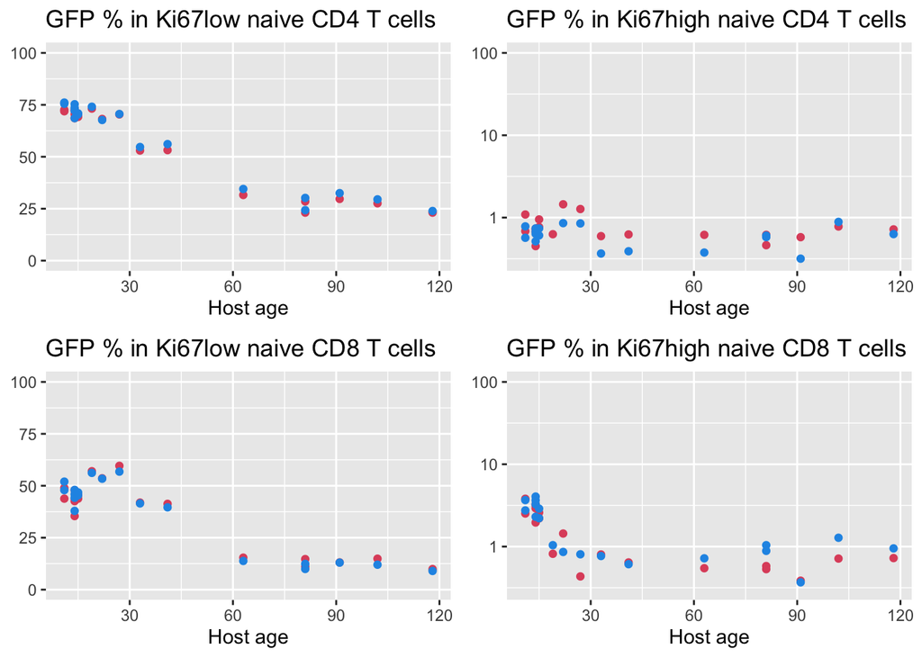

### Age distriution of naive T cells in young mice.

To explain the dynamics of naive T cells during the neonatal phase we extrapolated the $\delta$-varying and $\rho$-varying age-structured models back to the birth of the hosts. In these PDE models, we track the distribution of cell ages within naive T cell population across the animal ages $N(a,t)$ as it evolves by the continuous influx of new cells of age 0 from the thymus and by the loss of preexisting cells within the population. We assume that the progeny of the dividing cells inherit the cell age from their parents.

Predictions of the age distribution of naive CD4 T cells using the $\delta$-varying age structured model and the parameters estimated from its fit to the busulfn chimera data.

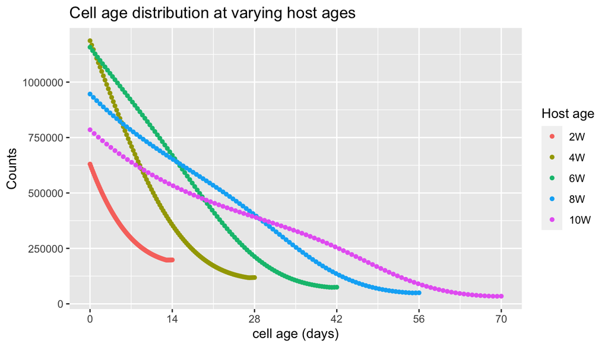

#### Transforming cell age distribution into the distribution of GFP intensities.

We assume that GFP expression on naive T cells declines exponentially with the time since their thymic exit (*i.e.* cell age), since there is no residual RAG activity in peripheral T cell populations. Our analysis of busulfan chimera data (?and simulations of counts and Ki67 expression in neonates?) predicts extremely slow rate of cell division in naive T cells, which means that loss of GFP through cell division is minimal. Therefore, recently emigrated naive cells of age = 0 are assumed to have the highest GFP expression ($f_\text{max}$), which declines as $f(a) = f_\text{max} \, e^{-\gamma \, a}$. This direct correlation between cell age ‘a’ and GFP intensity ‘f’ can be used to recast the age distribution N(a, t) as,

$$\begin{align}
N(f,t) &= N(a,t) \, \bigg\lvert\frac{da}{df}\bigg\rvert \\
&= N\bigg(\frac{ln f_\text{max} - ln f}{\gamma}, t \bigg) \, \frac{1}{\gamma \, f}; \\
\end{align}$$

We normalize GFP intensity by dividing it with the maximum observed fluorescence such that $f_\text{max} = 1$ and scan over the values of the GFP loss rate ($\gamma$) to make predictions of the GFP distribution.

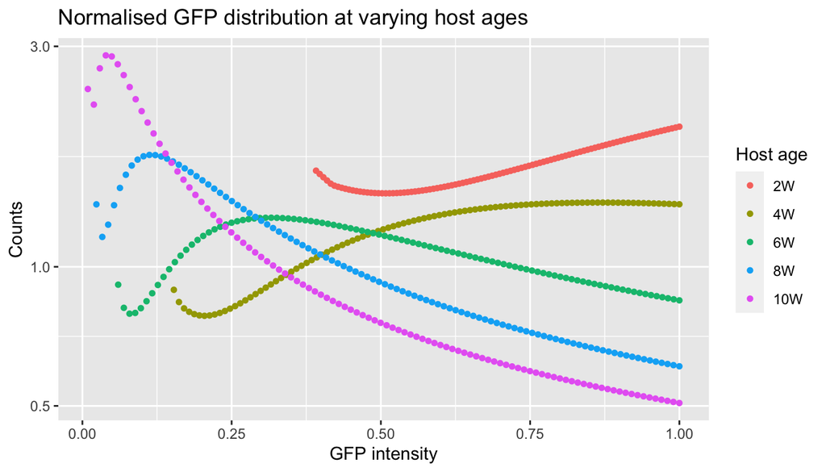

#### Calculating fraction of GFP$^+$ cells.

Total number of naive T cells observed as GFP positive can then be estimated by integrating $N(f,t)$ from the threshold gfp intensity $\bar{f}$ to $f_\text{max} = 1.0$. At any host age, the lowest GFP intensity can be caculated using $\gamma$ such that $f_\text{min} = f_\text{max} e^{-\gamma \, t}.$ Therefore, the fraction of GFPpostive cells in naive T cells can be derived as,

$$Z(f, t) = \frac{\int_{\bar{f}}^1 N(f,t)}{\int_{f_\text{min}}^1 N(f,t) \, df}.$$
Predictions of GFP fraction time-course using $\bar{f} = 0.3$ and the half life of GFP expression ~10 days *i.e.* $\gamma=0.067$.

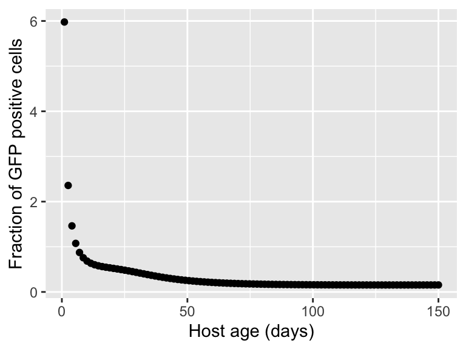